# Lesson 12

Timothy Luna

8/27/2019

# 2C-L2 Convolution in the Frequency Domain

## Intro

This is a continuation of the discussion on frequency analysis and frequency components; last lesson was about decomposing an image represented as a basis set of frequencies into the individual frequency components. The motivation was the neat Abraham Lincoln photo.

The task is to decompose an image into linearly independent, orthogonal, basis set which linearly span the signal.

This is the Fourier set which is a set of sinusoidals that we can reconstruct images with; this is related to the Fourier transform. The Fourier transform takes in a signal and outputs the magnitude and phase for a given frequency.

The idea behind the transform relies on the Euler representation of a sinusoidal.

The inverse transform aadds up all the sinusoids; We talked about both a two-dimensional and discrete inverse Fourier transform.

Normally we’re only interested in the *power* of the signal and therefore will ignore the phase.

*This* lesson relates the fourier transform to convolution and talks about how convolution in the spatial domain is multiplication in the frequency domain, and vice-versa.

## Fourier Transform and Convolution

Let’s suppose we have a convolution that results in g: $g = f * h$ (g is f convolved with h.)

Suppose you want the Fourier trasnform of g: $G(u) = \int_{-\infty}^{\infty} g(x) e^{-i 2 \pi u x} dx$

But g is the convolution of f with h so: $G(u) = \int_{-\infty}^{\infty} \int_{-\infty}^{\infty} f(\tau) h(x-\tau) e^{-i 2 \pi u x} d \tau d x$

This can be rearranged to begin isolating $\tau$: $G(u) = \int_{-\infty}^{\infty} \int_{-\infty}^{\infty} [f(\tau) e^{-i 2 \pi u \tau} d \tau ] [h(x-\tau) e^{-i 2 \pi u (x-\tau)} dx]$

Which can be recast with a change of variables: $G(u) = \int_{-\infty}^{\infty} [f(\tau) e^{-i 2 \pi u \tau} d \tau ] \int_{-\infty}^{\infty} [h(x') e^{-i 2 \pi u (x')} dx']$

A keen observer will recognize these terms from the last lecture as the *Fourier Transform of f ($\tau$)* and the Fourier transform of h.

This can now be rewritten as: $F(u)H(u)$

Look! Multiplication! Yay!

Remember that g was the convolution of f with h and G is the product of the Fourier transforms of f and h. So convolution in the spatial domain is multiplication in the frequency domin.

If you multiply in the spatial domain the Fourier transform of that function is the *convolution* in the frequency domain and vice-versa.

Symmetrical Transform Property

| Spatial | Frequency |
| --- | --- |
| g = f * h | G = F X H |
| g = f X h | G = F * H |

## FFT (Fast Fourier Transform)

If you want to convolve f with some BIG mask, which can be expensive, you can do it a slightly different way to save on time and computation.

Suppose you want to compute $g = f * h$ but either f, h, or both are very large?

You can take the Fourier transform of f and the Fourier transform of h (using the Fast Fourier Transform) and then multiply those two together to get the new Fourier transform and then do an inverse fourier trasnform. This can be *way* quicker!

## Smoothing and Blurring

How does the Fourier transform show you whats going on in the frequency domain?

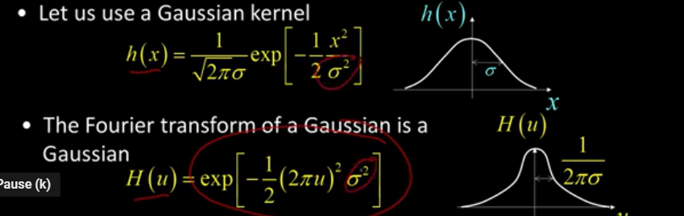

Think of a very skinny gaussian, almost like an impulse function. If the kernel is a very tight Gaussian then expect to keep all the frequencies, because nothing will be blurred out. But if the kernel is BIG and blurs everything expect to get nearly no high frequencies remaining and lots of low frequencies remaining.

The Fourier transform of a fat Gaussian, however, is skinny and the transform of a skinny Gaussian is fat.

What happens when we blur this function with a Gaussian is we multiply the Fourier transform by the Fourier transform of the Gaussian. This will retain the low values and reduce the highs. It *attenuates* the high frequencies.

## 2D Example

The 2d example still life in black and white (below) has a Fourier transform power spectra in bottom left. The origin (middle) is the lower frequencies. This is blurred with a 15 x 15 Gaussian, which appears very small as a result of the large image. When convolved with the image the result is a slightly blurry image returned.

In Fourier space the kernel is much bigger! We multiply the small Fourier of f by h and it attenuates *everything* not in the interior of the Fourier transform, attenuating the higher frequencies and blurring the image.

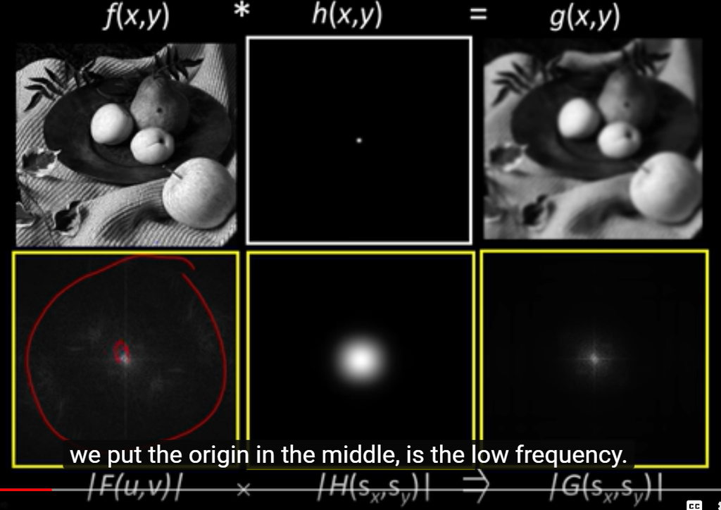

## Low and High Pass Filtering

We’ve seen this before when we talked about frequency (previous lesson.) This man made scene has large vertical uprghts. Here we have this pic and the inside of the filter sets all frequenciess outside a certain diameter (in frequency space) to 0. NO high freqs. This leads to ‘ringing’ where lower frequencies cannot be canceled out. This is what happens when you simply clip the frequencies.

If you remove JUST the center frequencies (coring) all that’s left is the high frequencies. This looks like the edges! (It is locations with steep derivatives.)

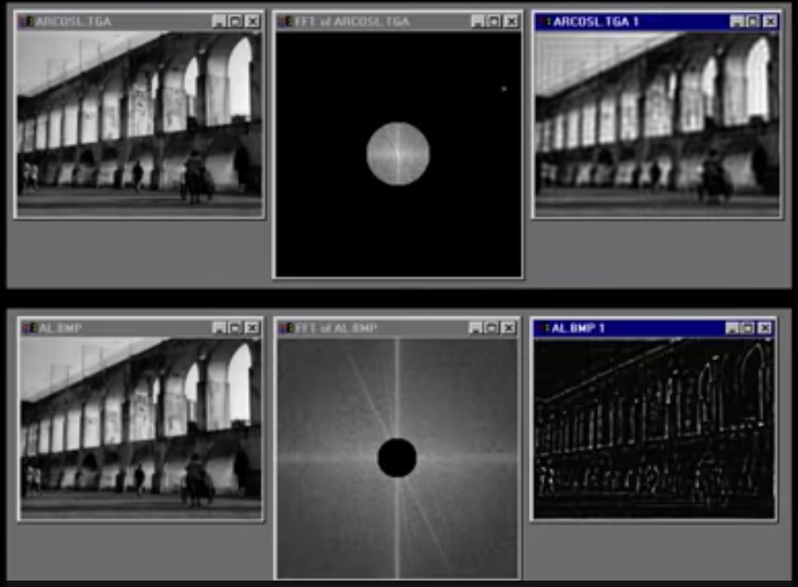

## Properties of the Fourier Transform

The differentation property multiplies the Fourier transform by a function proportional to the frequency. The higher frequencies are *accentuated* and the lower *attenuated*.

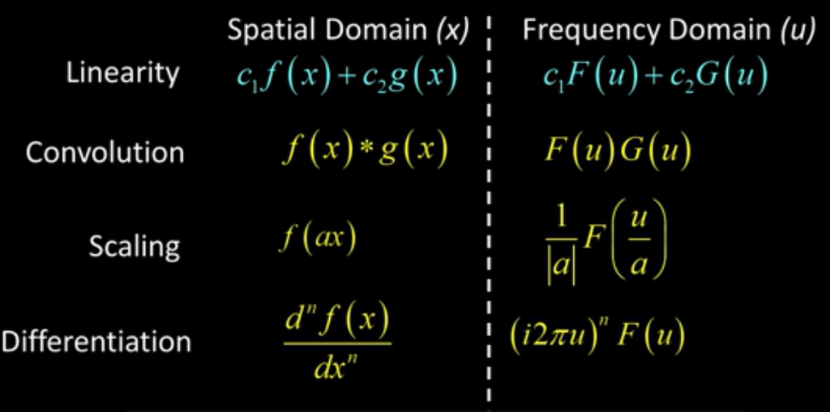

## Fourier Pairs

Rick Szeliskis book has a number of Fourier transform pairs to be used for convenience.

Most make sense, but what about a box function? A box in the spatial domain makes a *sink* which is $\frac{\sin(x)}{x}$. L’hospitals [^1] rule says that the limit as x goes to 0 is one. as x gets bigger, though, the sin gets attenuated and it tends toward zero.

If you convolve with a box filter weird stuff happens. This leads to striations and artifacting (seen in previous lessons.) This is from the ringing in the frequency domain. A Gaussian doesn’t cause ringing as much.

One more thing about sink functions. The Fourier transform of a box is a sink and the Fourier transform of a sink is a box.

What if we were to take some function, take the Fourier spectra and multiply by a box? That creates a ‘pillbox’ which is a box in 2D. This is the filter we just used to make ringing in the uprights image. It’s as if you convolved with the Fourier pair of sink.

Don’t ever just cut out the hgh frequencies! You’re essentially convolving with a sink function.

## End

Remember that ringing is caused by the Fourier transform of a box. Any hard cutoff in frequency or space can cause ringing.

[^1]: http://tutorial.math.lamar.edu/Classes/CalcI/LHospitalsRule.aspx